# ML Mini Project

```python
import numpy as np
import pandas as pd
import matplotlib.pyplot as plt
import seaborn as sns
import scipy.stats as st
from sklearn.model_selection import train_test_split
from sklearn.tree import DecisionTreeRegressor
from sklearn.metrics import r2_score, plot_roc_curve
from sklearn.metrics import accuracy_score,recall_score,precision_score,f1_score,auc, classification_report, roc_auc_score, confusion_matrix
from warnings import filterwarnings
filterwarnings('ignore')
```

```python
branch = pd.read_csv("Branch_ID_Master.csv")
```

```python
branch
```

|  | Branch_Id | Region_Code |
| --- | --- | --- |
| 0 | 1 | R3 |
| 1 | 2 | R3 |
| 2 | 3 | R3 |
| 3 | 5 | R3 |
| 4 | 7 | R3 |
| ... | ... | ... |
| 77 | 257 | R1 |
| 78 | 258 | R1 |
| 79 | 259 | R1 |
| 80 | 260 | R1 |
| 81 | 261 | R1 |

82 rows × 2 columns

```python
postal = pd.read_excel("Postal_Code_Master.xlsx")
```

```python
postal
```

|  | City_Code | City_Name | Postal_Code |
| --- | --- | --- | --- |
| 0 | CT01 | Mumbai | 400001 |
| 1 | CT01 | Mumbai | 400053 |
| 2 | CT01 | Mumbai | 422001 |
| 3 | CT02 | Pune | 411002 |
| 4 | CT02 | Pune | 411006 |
| 5 | CT03 | Chennai | 600020 |
| 6 | CT03 | Chennai | 600018 |
| 7 | CT04 | Coimbatore | 642205 |
| 8 | CT04 | Coimbatore | 642002 |
| 9 | CT05 | Hyderabad | 500004 |
| 10 | CT05 | Hyderabad | 500045 |
| 11 | CT06 | Jaipur | 302029 |
| 12 | CT06 | Jaipur | 302013 |
| 13 | CT07 | Kochi | 682001 |
| 14 | CT07 | Kochi | 686692 |
| 15 | CT08 | Kolkata | 700027 |
| 16 | CT08 | Kolkata | 700005 |
| 17 | CT09 | Delhi | 110039 |
| 18 | CT10 | Bangalore | 560034 |
| 19 | CT10 | Bangalore | 560002 |
| 20 | CT10 | Bangalore | 560063 |
| 21 | CT10 | Bangalore | 560030 |
| 22 | CT11 | Ahmedabad | 382460 |
| 23 | CT11 | Ahmedabad | 382220 |
| 24 | CT12 | Noida | 201301 |
| 25 | CT12 | Noida | 203155 |
| 26 | CT13 | Patna | 801110 |
| 27 | CT14 | Surat | 394651 |
| 28 | CT14 | Surat | 394620 |
| 29 | CT15 | Bhubaneshwar | 751022 |
| 30 | CT16 | Gangtok | 737101 |
| 31 | CT17 | Vadodara | 391510 |
| 32 | CT18 | Ludhiana | 141003 |
| 33 | CT19 | Mysore | 570028 |
| 34 | CT20 | kanpur | 208002 |
| 35 | CT21 | Dehradun | 248141 |
| 36 | CT22 | Indore | 453551 |
| 37 | CT22 | Indore | 452003 |
| 38 | CT23 | Mangalore | 575001 |
| 39 | CT23 | Mangalore | 574142 |
| 40 | CT24 | Thrissur | 680503 |
| 41 | CT24 | Thrissur | 680001 |
| 42 | CT25 | Nellore | 524225 |
| 43 | CT26 | Aurangabad | 431001 |
| 44 | CT27 | Jamshedpur | 832102 |
| 45 | CT27 | Jamshedpur | 831001 |
| 46 | CT28 | Ranchi | 834008 |
| 47 | CT28 | Ranchi | 835204 |
| 48 | CT29 | Vellore | 632001 |

```python
region = pd.read_excel("Region_Master.xlsx")
```

```python
region
```

|  | Region_ID | Region_Name |
| --- | --- | --- |
| 0 | R1 | North |
| 1 | R2 | South |
| 2 | R3 | East |
| 3 | R4 | West |

```python
loandet = pd.read_csv("Loan_Details_Transactions.csv")
```

```python
loandet.head()
```

|  | Loan_Id | Disbursed_Amount | Asset_Cost | ltv | Branch_Id | City_Code | State_Code | Postal_Code | Date_of_Birth | Employment_Type | ... | MobileNo_Avl_Flag | Aadhar_flag | PAN_flag | VoterID_flag | Driving_flag | Passport_flag | PERFORM_CNS.SCORE | DELINQUENT.ACCTS.IN.LAST.SIX.MONTHS | CREDIT.HISTORY.LENGTH | NO.OF_INQUIRIES |
| --- | --- | --- | --- | --- | --- | --- | --- | --- | --- | --- | --- | --- | --- | --- | --- | --- | --- | --- | --- | --- | --- |
| 0 | 1 | 36439 | 65850 | 56.19 | 64 | CT01 | ST15 | 400001 | 14-06-1990 | Self employed | ... | 1 | 1 | 0 | 0 | 0 | 0 | 0 | 0 | 0yrs 0mon | 0 |
| 1 | 2 | 48749 | 69303 | 72.15 | 67 | CT03 | ST24 | 600020 | 01-01-1991 | Salaried | ... | 1 | 1 | 0 | 0 | 0 | 0 | 783 | 0 | 2yrs 6mon | 0 |
| 2 | 3 | 55348 | 66340 | 85.00 | 2 | CT13 | ST04 | 801110 | 16-08-1993 | Self employed | ... | 1 | 1 | 0 | 0 | 0 | 0 | 0 | 0 | 0yrs 0mon | 0 |
| 3 | 4 | 48849 | 64133 | 77.96 | 217 | CT06 | ST22 | 302029 | 01-01-1989 | Self employed | ... | 1 | 1 | 0 | 0 | 0 | 0 | 0 | 0 | 0yrs 0mon | 0 |
| 4 | 5 | 40394 | 59386 | 70.72 | 74 | CT03 | ST24 | 600020 | 31-12-1974 | Self employed | ... | 1 | 1 | 0 | 0 | 0 | 0 | 14 | 1 | 3yrs 1mon | 1 |

5 rows × 21 columns

```python
loandet.shape
```

```
(23315, 21)
```

```python
loanstatus = pd.read_csv("Loan_status_mapping.csv")
```

```python
loanstatus.head()
```

|  | Loan_Id | Loan_Default |
| --- | --- | --- |
| 0 | 1 | 0 |
| 1 | 2 | 0 |
| 2 | 3 | 1 |
| 3 | 4 | 0 |
| 4 | 5 | 0 |

```python
loanstatus.shape
```

```
(23315, 2)
```

```python
df = loandet.merge(loanstatus,on="Loan_Id")
df.head()
```

|  | Loan_Id | Disbursed_Amount | Asset_Cost | ltv | Branch_Id | City_Code | State_Code | Postal_Code | Date_of_Birth | Employment_Type | ... | Aadhar_flag | PAN_flag | VoterID_flag | Driving_flag | Passport_flag | PERFORM_CNS.SCORE | DELINQUENT.ACCTS.IN.LAST.SIX.MONTHS | CREDIT.HISTORY.LENGTH | NO.OF_INQUIRIES | Loan_Default |
| --- | --- | --- | --- | --- | --- | --- | --- | --- | --- | --- | --- | --- | --- | --- | --- | --- | --- | --- | --- | --- | --- |
| 0 | 1 | 36439 | 65850 | 56.19 | 64 | CT01 | ST15 | 400001 | 14-06-1990 | Self employed | ... | 1 | 0 | 0 | 0 | 0 | 0 | 0 | 0yrs 0mon | 0 | 0 |
| 1 | 2 | 48749 | 69303 | 72.15 | 67 | CT03 | ST24 | 600020 | 01-01-1991 | Salaried | ... | 1 | 0 | 0 | 0 | 0 | 783 | 0 | 2yrs 6mon | 0 | 0 |
| 2 | 3 | 55348 | 66340 | 85.00 | 2 | CT13 | ST04 | 801110 | 16-08-1993 | Self employed | ... | 1 | 0 | 0 | 0 | 0 | 0 | 0 | 0yrs 0mon | 0 | 1 |
| 3 | 4 | 48849 | 64133 | 77.96 | 217 | CT06 | ST22 | 302029 | 01-01-1989 | Self employed | ... | 1 | 0 | 0 | 0 | 0 | 0 | 0 | 0yrs 0mon | 0 | 0 |
| 4 | 5 | 40394 | 59386 | 70.72 | 74 | CT03 | ST24 | 600020 | 31-12-1974 | Self employed | ... | 1 | 0 | 0 | 0 | 0 | 14 | 1 | 3yrs 1mon | 1 | 0 |

5 rows × 22 columns

```python
df.duplicated().sum()
```

```
0
```

```python
def miss_val(df):
    misval = df.isnull().sum()
    miss_per = 100 * misval/len(df)
    df1 = pd.concat([misval,miss_per],axis=1)
    renamed = df1.rename(columns={0:'missing_val',1:'missing %'})
    new = renamed[renamed.iloc[:,1] !=0].sort_values('missing_val',ascending=False)
    return new
```

```python
miss_val(df)
```

|  | missing_val | missing % |
| --- | --- | --- |
| Employment_Type | 770 | 3.302595 |

```python
!pip install missingno
```

```python
import missingno as ms
```

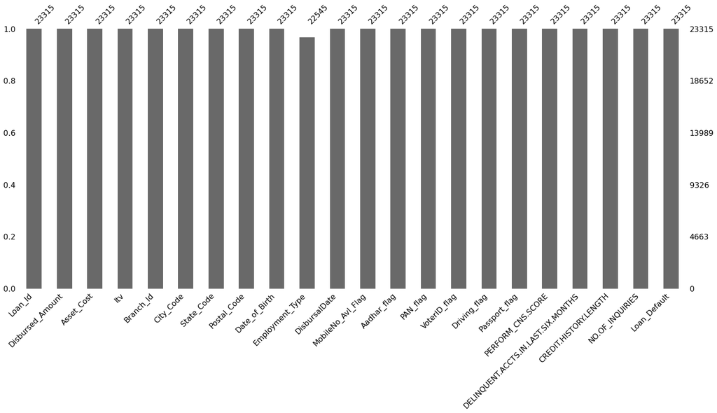

```python
ms.bar(df)
```

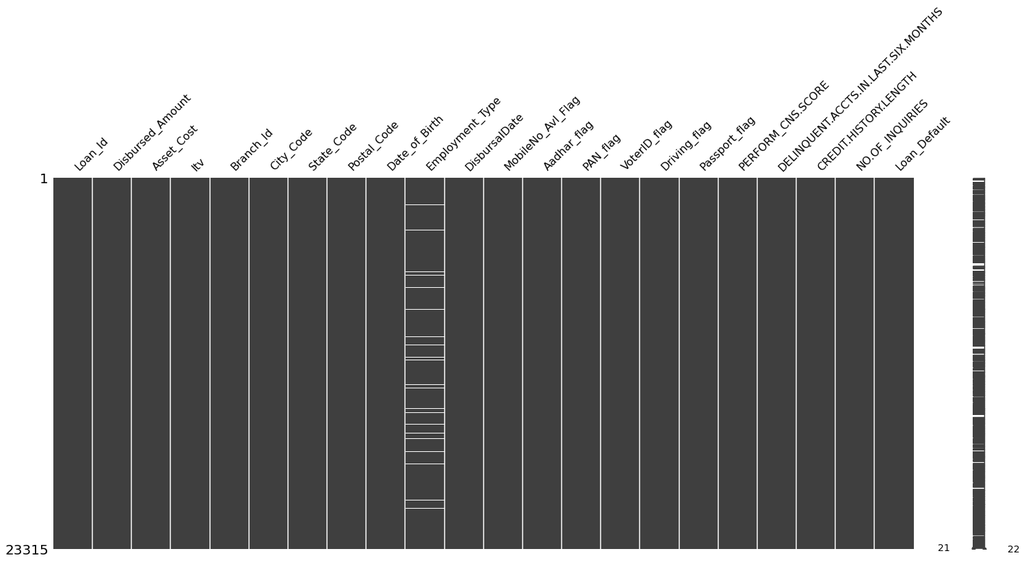

```python
ms.matrix(df)
```

# Outliers

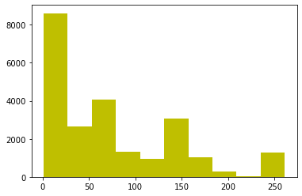

```python
plt.hist(df['Branch_Id'],color='y',bins=10)
```

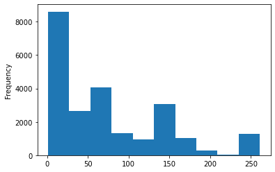

```python
df['Branch_Id'].plot(kind='hist')
```

```python
df['Branch_Id'].describe()
```

```
count    23315.000000
mean        72.079262
std         69.095008
min          1.000000
25%         13.000000
50%         61.000000
75%        121.000000
max        261.000000
Name: Branch_Id, dtype: float64
```

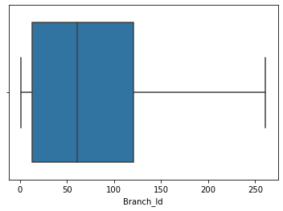

```python
sns.boxplot(df['Branch_Id'])
```

# Data Transformation

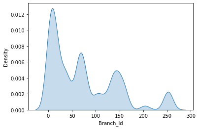

```python
sns.kdeplot(df["Branch_Id"],shade=True)
```

```python
df["log_sold"] = np.log(df["Branch_Id"])
```

```python
df.head()
```

|  | Loan_Id | Disbursed_Amount | Asset_Cost | ltv | Branch_Id | City_Code | State_Code | Postal_Code | Date_of_Birth | Employment_Type | ... | PAN_flag | VoterID_flag | Driving_flag | Passport_flag | PERFORM_CNS.SCORE | DELINQUENT.ACCTS.IN.LAST.SIX.MONTHS | CREDIT.HISTORY.LENGTH | NO.OF_INQUIRIES | Loan_Default | log_sold |
| --- | --- | --- | --- | --- | --- | --- | --- | --- | --- | --- | --- | --- | --- | --- | --- | --- | --- | --- | --- | --- | --- |
| 0 | 1 | 36439 | 65850 | 56.19 | 64 | CT01 | ST15 | 400001 | 14-06-1990 | Self employed | ... | 0 | 0 | 0 | 0 | 0 | 0 | 0yrs 0mon | 0 | 0 | 4.158883 |
| 1 | 2 | 48749 | 69303 | 72.15 | 67 | CT03 | ST24 | 600020 | 01-01-1991 | Salaried | ... | 0 | 0 | 0 | 0 | 783 | 0 | 2yrs 6mon | 0 | 0 | 4.204693 |
| 2 | 3 | 55348 | 66340 | 85.00 | 2 | CT13 | ST04 | 801110 | 16-08-1993 | Self employed | ... | 0 | 0 | 0 | 0 | 0 | 0 | 0yrs 0mon | 0 | 1 | 0.693147 |
| 3 | 4 | 48849 | 64133 | 77.96 | 217 | CT06 | ST22 | 302029 | 01-01-1989 | Self employed | ... | 0 | 0 | 0 | 0 | 0 | 0 | 0yrs 0mon | 0 | 0 | 5.379897 |
| 4 | 5 | 40394 | 59386 | 70.72 | 74 | CT03 | ST24 | 600020 | 31-12-1974 | Self employed | ... | 0 | 0 | 0 | 0 | 14 | 1 | 3yrs 1mon | 1 | 0 | 4.304065 |

5 rows × 23 columns

```python
def transformed_var(df,var):
    plt.figure(figsize=(10,8))
    plt.subplot(1,2,1)
    df[var].hist()
    plt.subplot(1,2,2)
    st.probplot(df[var],dist='norm',plot=plt)
    plt.show()
```

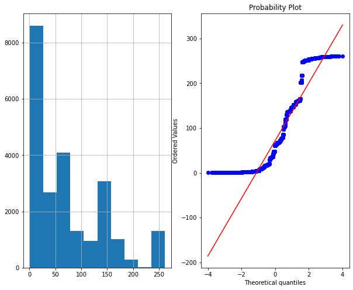

```python
transformed_var(df,'Branch_Id')
```

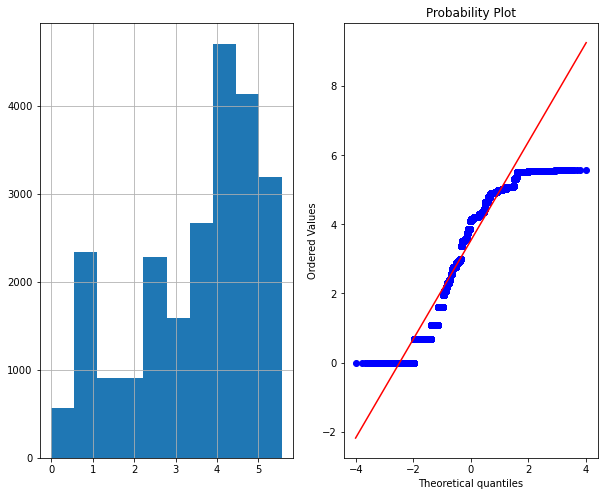

```python
transformed_var(df,'log_sold')
```

#### Summary

1. Approximately better compared to previous one- Follow normal distribution
2. Most of the data points lie on the 45 deg line in th probability plot except the initial and the last points

```python
# Squareroot transformation

df["Branch_Id"] = np.sqrt(df["Branch_Id"])
```

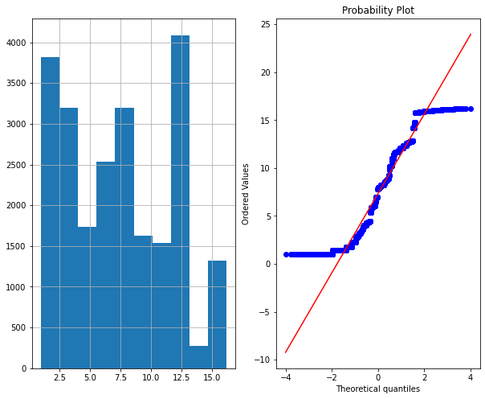

```python
transformed_var(df,'Branch_Id')
```

#### Summary

1. Square root transformation - Histogram and probability plot
2. Approx normal distribution

```python
# Cube root transformation
df["Branch_Id"] = np.cbrt(df['Branch_Id'])
```

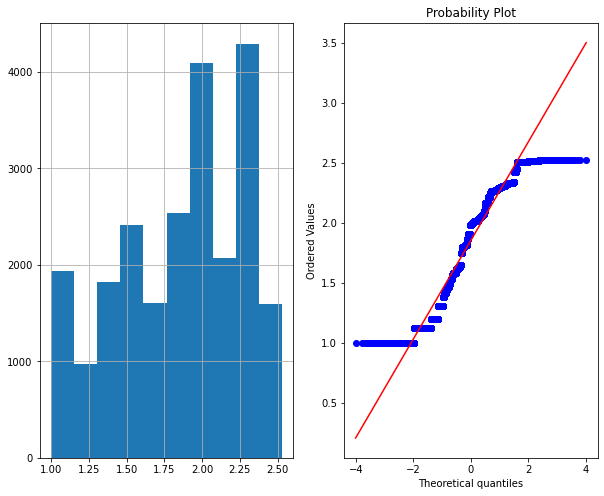

```python
transformed_var(df,'Branch_Id')
```

# Hypothesis Testing

```python
df.City_Code.value_counts()
```

```
CT17    873
CT02    861
CT15    842
CT10    840
CT19    832
CT18    830
CT23    820
CT26    820
CT27    818
CT04    817
CT24    816
CT11    805
CT20    805
CT12    803
CT13    802
CT01    801
CT22    800
CT07    798
CT21    797
CT03    794
CT06    790
CT14    780
CT05    779
CT09    777
CT28    776
CT08    768
CT29    767
CT16    752
CT25    752
Name: City_Code, dtype: int64
```

```python
df.Employment_Type.value_counts()
```

```
Self employed    12724
Salaried          9821
Name: Employment_Type, dtype: int64
```

```python
df.shape
```

```
(23315, 23)
```

```python
df.describe()
```

|  | Loan_Id | Disbursed_Amount | Asset_Cost | ltv | Branch_Id | Postal_Code | MobileNo_Avl_Flag | Aadhar_flag | PAN_flag | VoterID_flag | Driving_flag | Passport_flag | PERFORM_CNS.SCORE | DELINQUENT.ACCTS.IN.LAST.SIX.MONTHS | NO.OF_INQUIRIES | Loan_Default | log_sold |
| --- | --- | --- | --- | --- | --- | --- | --- | --- | --- | --- | --- | --- | --- | --- | --- | --- | --- |
| count | 23315.000000 | 23315.000000 | 23315.000000 | 23315.000000 | 23315.000000 | 23315.000000 | 23315.0 | 23315.000000 | 23315.000000 | 23315.000000 | 23315.000000 | 23315.000000 | 23315.000000 | 23315.000000 | 23315.000000 | 23315.000000 | 23315.000000 |
| mean | 11658.000000 | 54297.647309 | 75842.182887 | 74.701607 | 1.855852 | 505937.177439 | 1.0 | 0.845078 | 0.075531 | 0.141068 | 0.023161 | 0.002059 | 291.234956 | 0.100622 | 0.205790 | 0.219858 | 3.536796 |
| std | 6730.605099 | 13061.877434 | 18988.525635 | 11.462722 | 0.421283 | 204520.532113 | 0.0 | 0.361838 | 0.264252 | 0.348099 | 0.150418 | 0.045328 | 338.490214 | 0.388782 | 0.699901 | 0.414159 | 1.487296 |
| min | 1.000000 | 13369.000000 | 37230.000000 | 17.130000 | 1.000000 | 110039.000000 | 1.0 | 0.000000 | 0.000000 | 0.000000 | 0.000000 | 0.000000 | 0.000000 | 0.000000 | 0.000000 | 0.000000 | 0.000000 |
| 25% | 5829.500000 | 46949.000000 | 65629.000000 | 68.830000 | 1.533406 | 391510.000000 | 1.0 | 1.000000 | 0.000000 | 0.000000 | 0.000000 | 0.000000 | 0.000000 | 0.000000 | 0.000000 | 0.000000 | 2.564949 |
| 50% | 11658.000000 | 53759.000000 | 70929.000000 | 76.710000 | 1.984061 | 524225.000000 | 1.0 | 1.000000 | 0.000000 | 0.000000 | 0.000000 | 0.000000 | 0.000000 | 0.000000 | 0.000000 | 0.000000 | 4.110874 |
| 75% | 17486.500000 | 60379.000000 | 79354.500000 | 83.630000 | 2.223980 | 680503.000000 | 1.0 | 1.000000 | 0.000000 | 0.000000 | 0.000000 | 0.000000 | 679.000000 | 0.000000 | 0.000000 | 0.000000 | 4.795791 |
| max | 23315.000000 | 592460.000000 | 715186.000000 | 94.980000 | 2.527979 | 834008.000000 | 1.0 | 1.000000 | 1.000000 | 1.000000 | 1.000000 | 1.000000 | 890.000000 | 7.000000 | 23.000000 | 1.000000 | 5.564520 |

# Test of Normality

Normality:The population data sould follow normal ( by default alpha =5%) H0: pop data = Normal

H1: pop data != normal

Note: if p value >=alpha --> pop data = Normal

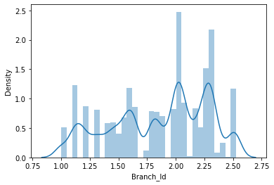

```python
sns.distplot(df.Branch_Id)
```

```python
st.shapiro(df.Branch_Id)
```

```
ShapiroResult(statistic=0.9462637305259705, pvalue=0.0)
```

# Since p value <alpha (0.05) --> reject H0.

Hence we can conclude that pop data of total bill does not folow normal distribution

So we can not do the parametric test. proceed for non parametric test

Test of Median H0: pop median_total bill >=25

H1:pop median_total Bill <25

```python
pop_median=25
alpha = 0.05
diff_median = df.Branch_Id-pop_median
```

```python
## Wilcoxon  test
st.wilcoxon(diff_median, alternative='less')
```

```
WilcoxonResult(statistic=0.0, pvalue=0.0)
```

# 2. Independent Samples Test

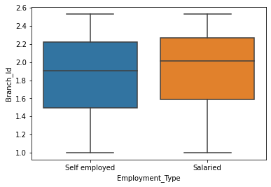

```python
sns.boxplot(x=df.Employment_Type,y=df.Branch_Id)
```

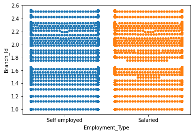

```python
sns.swarmplot(x=df.Employment_Type, y=df.Branch_Id, data=df)
```

```python
tb_Se= df[df.Employment_Type=='Self employed']['Branch_Id']
tb_e= df[df.Employment_Type=='Salaried']['Branch_Id']
```

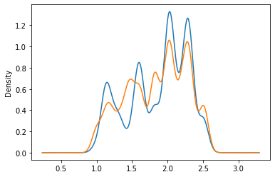

```python
df.groupby('Employment_Type')['Branch_Id'].plot.density();
```

```python
df.groupby('Employment_Type')['Branch_Id'].describe()
```

| Employment_Type | count | mean | std | min | 25% | 50% | 75% | max |
| --- | --- | --- | --- | --- | --- | --- | --- | --- |
| Salaried | 9821.0 | 1.869574 | 0.419571 | 1.0 | 1.587401 | 2.010284 | 2.264934 | 2.527979 |
| Self employed | 12724.0 | 1.845497 | 0.423111 | 1.0 | 1.491301 | 1.906369 | 2.220906 | 2.527979 |

Test of Normality for both Self employed Branch_Id and Salaried Branch_Id

```python
st.shapiro(tb_Se)
```

```
ShapiroResult(statistic=0.9553775787353516, pvalue=0.0)
```

```python
st.shapiro(tb_e)
```

```
ShapiroResult(statistic=0.9276606440544128, pvalue=0.0)
```

# Mann Whitney U Test

Ho: pop median_tb_Se = pop median_tb_e

H1: pop median_tb_Se != pop median_tb_e

```python
st.mannwhitneyu(tb_Se,tb_e,alternative='two-sided')
```

```
MannwhitneyuResult(statistic=60051078.0, pvalue=5.242054833407218e-07)
```

# test of Variance equality - Levene test

H0: pop1 _variance = pop2 Variance

H1: pop1 _variance != pop2 Variance

Note: if p value >= alpha--> pop variances are equal

```python
st.levene(tb_Se,tb_e)
```

```
LeveneResult(statistic=14.54793039374196, pvalue=0.0001370028230183985)
```

H0: pop_mean_tb_Se = pop_mean_tb_e ** mu_tbSe-mu_tb_e=0

H1: pop_mean_tb_Se != pop_mean_tb_e ** mu_tbm-mu_tb_e!=0

```python
st.ttest_ind(tb_Se, tb_e, equal_var=True)
```

```
Ttest_indResult(statistic=-4.251905647105296, pvalue=2.128120797359904e-05)
```

```python
alpha=0.05
x1= tb_Se.mean()
x2= tb_e.mean()
s1_2= tb_Se.var()
s2_2= tb_e.var()
n1= len(tb_Se)
n2= len(tb_e)
pooled_var= ((n1-1)*s1_2+(n2-1)*s2_2)/(n1+n2-2)
std_error = np.sqrt(pooled_var*((1/n1)+(1/n2)))
t_st= (x1-x2)/std_error
t_crit = st.t.isf(alpha/2, n1+n2-2)
print(t_st, t_crit)
```

```
-4.251905647100019 1.9600692232589663
```

```python
p_value= st.t.sf(t_st, n1+n2-2)*2
p_value
```

```
1.999978718792026
```

```python
st.ttest_ind(tb_Se, tb_e, equal_var=False)
```

```
Ttest_indResult(statistic=-4.256508942323021, pvalue=2.0853583550074495e-05)
```

# Goodness of fit: - Chi sqaure test - Applications

Test whether the random generating machine is fit randomness with the below data rin for 100 times?

```python
obs= np.array([20,24,26,30])
exp = np.array([25,25,25,25])
```

```python
## Method 1
chi2_stat= ((obs**2/exp).sum()) -(obs.sum())
chi2_stat
```

```
2.0799999999999983
```

```python
## Method 2
chisquarr_stat= (((obs-exp)**2)/exp).sum()
chisquarr_stat
```

```
2.08
```

```python
## p value; ## Chi square critcal
print(" p value: ", st.chi2.sf(chisquarr_stat,3),";", "critical value: ",st.chi2.isf(alpha,3))
```

```
 p value:  0.5559694842870644 ; critical value:  7.814727903251178
```

```python
st.chisquare(obs,exp)
```

```
Power_divergenceResult(statistic=2.08, pvalue=0.5559694842870644)
```

```python
df.Branch_Id.describe()
```

```
count    23315.000000
mean         1.855852
std          0.421283
min          1.000000
25%          1.533406
50%          1.984061
75%          2.223980
max          2.527979
Name: Branch_Id, dtype: float64
```

# Modelling

```python
x = df.drop(['NO.OF_INQUIRIES','Disbursed_Amount'],axis=1)
y = df['Loan_Default']
```

```python
from sklearn.preprocessing import StandardScaler, MinMaxScaler
cnames = ["Asset_Cost", "Branch_Id"]
sc = MinMaxScaler()
for col in cnames:
    x[col] = sc.fit_transform(x[col].values.reshape(-1,1))
```

```python
x.head()
```

|  | Loan_Id | Asset_Cost | ltv | Branch_Id | City_Code | State_Code | Postal_Code | Date_of_Birth | Employment_Type | DisbursalDate | ... | Aadhar_flag | PAN_flag | VoterID_flag | Driving_flag | Passport_flag | PERFORM_CNS.SCORE | DELINQUENT.ACCTS.IN.LAST.SIX.MONTHS | CREDIT.HISTORY.LENGTH | Loan_Default | log_sold |
| --- | --- | --- | --- | --- | --- | --- | --- | --- | --- | --- | --- | --- | --- | --- | --- | --- | --- | --- | --- | --- | --- |
| 0 | 1 | 0.042215 | 56.19 | 0.654459 | CT01 | ST15 | 400001 | 14-06-1990 | Self employed | 28-09-2018 | ... | 1 | 0 | 0 | 0 | 0 | 0 | 0 | 0yrs 0mon | 0 | 4.158883 |
| 1 | 2 | 0.047308 | 72.15 | 0.664491 | CT03 | ST24 | 600020 | 01-01-1991 | Salaried | 10-09-2018 | ... | 1 | 0 | 0 | 0 | 0 | 783 | 0 | 2yrs 6mon | 0 | 4.204693 |
| 2 | 3 | 0.042938 | 85.00 | 0.080146 | CT13 | ST04 | 801110 | 16-08-1993 | Self employed | 31-08-2018 | ... | 1 | 0 | 0 | 0 | 0 | 0 | 0 | 0yrs 0mon | 1 | 0.693147 |
| 3 | 4 | 0.039683 | 77.96 | 0.949867 | CT06 | ST22 | 302029 | 01-01-1989 | Self employed | 13-10-2018 | ... | 1 | 0 | 0 | 0 | 0 | 0 | 0 | 0yrs 0mon | 0 | 5.379897 |
| 4 | 5 | 0.032681 | 70.72 | 0.686518 | CT03 | ST24 | 600020 | 31-12-1974 | Self employed | 14-09-2018 | ... | 1 | 0 | 0 | 0 | 0 | 14 | 1 | 3yrs 1mon | 0 | 4.304065 |

5 rows × 21 columns

```python
x = pd.get_dummies(x,drop_first=True)
```

```python
x
```

|  | Loan_Id | Asset_Cost | ltv | Branch_Id | Postal_Code | MobileNo_Avl_Flag | Aadhar_flag | PAN_flag | VoterID_flag | Driving_flag | ... | CREDIT.HISTORY.LENGTH_9yrs 11mon | CREDIT.HISTORY.LENGTH_9yrs 1mon | CREDIT.HISTORY.LENGTH_9yrs 2mon | CREDIT.HISTORY.LENGTH_9yrs 3mon | CREDIT.HISTORY.LENGTH_9yrs 4mon | CREDIT.HISTORY.LENGTH_9yrs 5mon | CREDIT.HISTORY.LENGTH_9yrs 6mon | CREDIT.HISTORY.LENGTH_9yrs 7mon | CREDIT.HISTORY.LENGTH_9yrs 8mon | CREDIT.HISTORY.LENGTH_9yrs 9mon |
| --- | --- | --- | --- | --- | --- | --- | --- | --- | --- | --- | --- | --- | --- | --- | --- | --- | --- | --- | --- | --- | --- |
| 0 | 1 | 0.042215 | 56.19 | 0.654459 | 400001 | 1 | 1 | 0 | 0 | 0 | ... | 0 | 0 | 0 | 0 | 0 | 0 | 0 | 0 | 0 | 0 |
| 1 | 2 | 0.047308 | 72.15 | 0.664491 | 600020 | 1 | 1 | 0 | 0 | 0 | ... | 0 | 0 | 0 | 0 | 0 | 0 | 0 | 0 | 0 | 0 |
| 2 | 3 | 0.042938 | 85.00 | 0.080146 | 801110 | 1 | 1 | 0 | 0 | 0 | ... | 0 | 0 | 0 | 0 | 0 | 0 | 0 | 0 | 0 | 0 |
| 3 | 4 | 0.039683 | 77.96 | 0.949867 | 302029 | 1 | 1 | 0 | 0 | 0 | ... | 0 | 0 | 0 | 0 | 0 | 0 | 0 | 0 | 0 | 0 |
| 4 | 5 | 0.032681 | 70.72 | 0.686518 | 600020 | 1 | 1 | 0 | 0 | 0 | ... | 0 | 0 | 0 | 0 | 0 | 0 | 0 | 0 | 0 | 0 |
| ... | ... | ... | ... | ... | ... | ... | ... | ... | ... | ... | ... | ... | ... | ... | ... | ... | ... | ... | ... | ... | ... |
| 23310 | 23311 | 0.218511 | 69.59 | 0.523497 | 600020 | 1 | 1 | 0 | 0 | 0 | ... | 0 | 0 | 0 | 0 | 0 | 0 | 0 | 0 | 0 | 0 |
| 23311 | 23312 | 0.126333 | 65.11 | 0.201351 | 751022 | 1 | 1 | 0 | 0 | 0 | ... | 0 | 0 | 0 | 0 | 0 | 0 | 0 | 0 | 0 | 0 |
| 23312 | 23313 | 0.044937 | 73.86 | 0.593181 | 453551 | 1 | 1 | 0 | 0 | 0 | ... | 0 | 0 | 0 | 0 | 0 | 0 | 0 | 0 | 0 | 0 |
| 23313 | 23314 | 0.069577 | 86.00 | 0.080146 | 600020 | 1 | 1 | 0 | 0 | 0 | ... | 0 | 0 | 0 | 0 | 0 | 0 | 0 | 0 | 0 | 0 |
| 23314 | 23315 | 0.050360 | 85.00 | 0.523497 | 110039 | 1 | 1 | 0 | 0 | 0 | ... | 0 | 0 | 0 | 0 | 0 | 0 | 0 | 0 | 0 | 0 |

23315 rows × 9083 columns

```python
xtrain,xtest,ytrain,ytest = train_test_split(x,y,test_size=0.25,random_state=10)
```

```python
print(f'xtrain shape:{xtrain.shape}')
print(f'xtest shape:{xtest.shape}')
print(f'ytrain shape:{ytrain.shape}')
print(f'ytest shape:{ytest.shape}')
```

```
xtrain shape:(17486, 9083)
xtest shape:(5829, 9083)
ytrain shape:(17486,)
ytest shape:(5829,)
```

```python
reg = DecisionTreeRegressor()
```

```python
reg.fit(xtrain,ytrain)
```

```
DecisionTreeRegressor()
```

```python
ypred = reg.predict(xtest)
```

```python
reg.score(xtest,ytest)
```

```
1.0
```

```python
r2_score(ytest,ypred)
```

```
1.0
```

```python
reg1 = DecisionTreeRegressor(max_depth=3)
```

```python
reg1.fit(xtrain,ytrain)
```

```
DecisionTreeRegressor(max_depth=3)
```

```python
ypred1 = reg1.predict(xtest)
```

```python
r2_score(ytest,ypred1)
```

```
1.0
```

```python
from sklearn.metrics import r2_score
```

```python
r2_score(ytest,ypred)
```

```
1.0
```

```python
reg1 = DecisionTreeRegressor(max_depth=3)
```

```python
reg1.fit(xtrain,ytrain)
```

```
DecisionTreeRegressor(max_depth=3)
```

```python
ypred1 = reg1.predict(xtest)
```

```python
r2_score(ytest,ypred1)
```

```
1.0
```

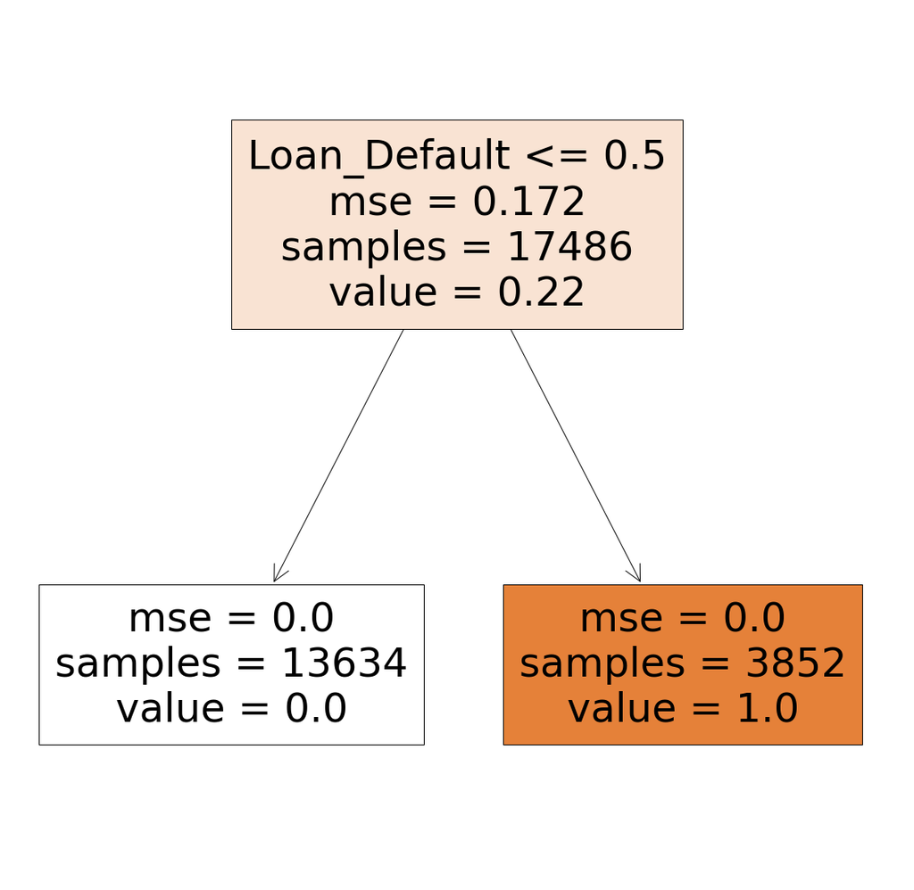

```python
from sklearn import tree
plt.figure(figsize=(20,20))
tree.plot_tree(reg1,feature_names=xtrain.columns,filled=True);
```

```python
#tree rules
treerules = tree.export_text(reg1,feature_names=list(xtrain.columns.values))
print(treerules)
```

```
|--- Loan_Default <= 0.50
|   |--- value: [0.00]
|--- Loan_Default >  0.50
|   |--- value: [1.00]
```

```python
from sklearn.neighbors import KNeighborsRegressor
```

```python
kr = KNeighborsRegressor()
```

```python
kr.fit(xtrain,ytrain)
ypred = kr.predict(xtest)
```

```python
r2_score(ytest,ypred)
```

```
-0.20407626997434147
```

```python
from sklearn.ensemble import GradientBoostingRegressor
```

```python
gbr = GradientBoostingRegressor(n_estimators=500)
```

```python
gbr.fit(xtrain,ytrain)
```

```
GradientBoostingRegressor(n_estimators=500)
```

```python
ypred = gbr.predict(xtest)
```

```python
from sklearn.metrics import r2_score,mean_squared_error
```

```python
r2_score(ytest,ypred)
```

```
1.0
```

```python
mean_squared_error(ytest,ypred)
```

```
5.977437250568898e-32
```

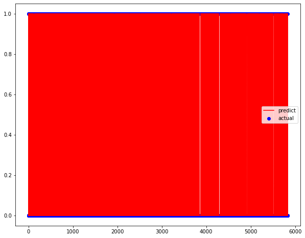

```python
x = range(len(ytest))
plt.figure(figsize=(10,8))
plt.scatter(x,ytest,color='b',label ='actual')
plt.plot(x,ypred,color='r',label='predict')
plt.legend()
plt.show()
```